# 2020 Fall STAT 430 Final Project --- Wine Data Cluster Analysis

Author: Shuyu Jia, Zhehui Chen

```python
# import libraries
import pandas as pd
import numpy as np
import matplotlib.pyplot as plt
import seaborn as sns
import matplotlib.cm as cm
from sklearn.preprocessing import StandardScaler
from pyclustertend import hopkins
from sklearn.manifold import TSNE
from sklearn.cluster import KMeans
from skfuzzy.cluster import cmeans
from sklearn.decomposition import PCA
from sklearn.cluster import AgglomerativeClustering
from scipy.spatial.distance import pdist
from scipy.cluster.hierarchy import linkage, dendrogram, cophenet
from sklearn.metrics import adjusted_rand_score, homogeneity_score, completeness_score, silhouette_score, silhouette_samples
%matplotlib inline
```

# 1. Dataset Introduction

The csv contained in the zip file contains the results of a chemical analysis of 178 wine samples grown in the same region in Italy but derived from three different cultivars. The analysis determined the quantities of 13 constituents (ie. attributes) found in each of the three types of wines. This dataset has pre-assigned class labels, which represent the three wine cultivars. See this link for more information. https://archive.ics.uci.edu/ml/datasets/Wine

```python
wine = pd.read_csv('wine.csv')
wine.head()
```

|  | Wine Class | Alcohol Content | Malic Acid | Ash | Alcalinity of Ash | Magnesium | Total Phenols | Flavanoids | Nonflavanoid Phenols | Proanthocyanins | Color Intensity | Hue | OD280 or OD315 of diluted wines | Proline |
| --- | --- | --- | --- | --- | --- | --- | --- | --- | --- | --- | --- | --- | --- | --- |
| 0 | 1 | 14.23 | 1.71 | 2.43 | 15.6 | 127 | 2.80 | 3.06 | 0.28 | 2.29 | 5.64 | 1.04 | 3.92 | 1065 |
| 1 | 1 | 13.20 | 1.78 | 2.14 | 11.2 | 100 | 2.65 | 2.76 | 0.26 | 1.28 | 4.38 | 1.05 | 3.40 | 1050 |
| 2 | 1 | 13.16 | 2.36 | 2.67 | 18.6 | 101 | 2.80 | 3.24 | 0.30 | 2.81 | 5.68 | 1.03 | 3.17 | 1185 |
| 3 | 1 | 14.37 | 1.95 | 2.50 | 16.8 | 113 | 3.85 | 3.49 | 0.24 | 2.18 | 7.80 | 0.86 | 3.45 | 1480 |
| 4 | 1 | 13.24 | 2.59 | 2.87 | 21.0 | 118 | 2.80 | 2.69 | 0.39 | 1.82 | 4.32 | 1.04 | 2.93 | 735 |

```python
wine.shape
```

```
(178, 14)
```

The wine dataset contains 178 rows (wine samples) and 13 attributes (with one class label).

# 2. Dataset Research

## 2.1 Motivation

Using this wine dataset, [1] visualized the clustering and predicted the classes, and found out that k-means clustering algorithm performs better than other clustering techniques such as PCA, LDA, SVM, etc. On the other hand, [2] tried to group similar observations together and determine the number of possible clusters since it may differ from 3, which would help the researcher make predictions and reduce dimensionality. For a more advanced technique, [3] introduced a new semi-supervised clustering algorithm that integrates both constraint-based methods and distance-function learning methods in a uniform framework, in order to produce better clusters than previously proposed clustering algorithms. The references are listed below.

**References:**

[1] Nath, Ayantika, and Shikha Nema. “Clustering Visualization and Class Prediction Using Flask of Benchmark Dataset for Unsupervised Techniques in Machine Learning.” International Journal of Innovative Technology and Exploring Engineering Regular Issue, vol. 9, no. 7, 2020, pp. 1297–1302., doi:10.35940/ijitee.g5943.059720. (http://www.ijitee.org/wp-content/uploads/papers/v9i7/G5943059720.pdf)

[2] Jankovic, Dina. “K-Means Clustering of Wine Data.” Medium, Towards Data Science, 13 Aug. 2018, towardsdatascience.com/k-means-clustering-of-wine-data-95bac074baae. (https://towardsdatascience.com/k-means-clustering-of-wine-data-95bac074baae)

[3] Bilenko, Mikhail, et al. “Integrating Constraints and Metric Learning in Semi-Supervised Clustering.” Twenty-First International Conference on Machine Learning - ICML '04, 2004, doi:10.1145/1015330.1015360. (https://www.cs.utexas.edu/~ml/papers/semi-icml-04.pdf)

Based on our literature research, we decided to use different types of clustering algorithm to grouup similar observations together, and to compare our clustering results with the ground truth.

## 2.2 Dataset Information

These data are the results of a chemical analysis of wines grown in the same region in Italy but derived from three different cultivars. The analysis determined the quantities of 13 constituents found in each of the three types of wines.

# 3. Data Cleaning

```python
# check for NA
wine.isnull().sum()
```

```
Wine Class                         0
Alcohol Content                    0
Malic Acid                         0
Ash                                0
Alcalinity of Ash                  0
Magnesium                          0
Total Phenols                      0
Flavanoids                         0
Nonflavanoid Phenols               0
Proanthocyanins                    0
Color Intensity                    0
Hue                                0
OD280 or OD315 of diluted wines    0
Proline                            0
dtype: int64
```

No missing values and the data looks fine.

```python
# check for data types
wine.dtypes
```

```
Wine Class                           int64
Alcohol Content                    float64
Malic Acid                         float64
Ash                                float64
Alcalinity of Ash                  float64
Magnesium                            int64
Total Phenols                      float64
Flavanoids                         float64
Nonflavanoid Phenols               float64
Proanthocyanins                    float64
Color Intensity                    float64
Hue                                float64
OD280 or OD315 of diluted wines    float64
Proline                              int64
dtype: object
```

All features are numerical.

```python
# feature matrix X
X = wine.copy()
X = X.drop('Wine Class', axis = 1)
X.head()
```

|  | Alcohol Content | Malic Acid | Ash | Alcalinity of Ash | Magnesium | Total Phenols | Flavanoids | Nonflavanoid Phenols | Proanthocyanins | Color Intensity | Hue | OD280 or OD315 of diluted wines | Proline |
| --- | --- | --- | --- | --- | --- | --- | --- | --- | --- | --- | --- | --- | --- |
| 0 | 14.23 | 1.71 | 2.43 | 15.6 | 127 | 2.80 | 3.06 | 0.28 | 2.29 | 5.64 | 1.04 | 3.92 | 1065 |
| 1 | 13.20 | 1.78 | 2.14 | 11.2 | 100 | 2.65 | 2.76 | 0.26 | 1.28 | 4.38 | 1.05 | 3.40 | 1050 |
| 2 | 13.16 | 2.36 | 2.67 | 18.6 | 101 | 2.80 | 3.24 | 0.30 | 2.81 | 5.68 | 1.03 | 3.17 | 1185 |
| 3 | 14.37 | 1.95 | 2.50 | 16.8 | 113 | 3.85 | 3.49 | 0.24 | 2.18 | 7.80 | 0.86 | 3.45 | 1480 |
| 4 | 13.24 | 2.59 | 2.87 | 21.0 | 118 | 2.80 | 2.69 | 0.39 | 1.82 | 4.32 | 1.04 | 2.93 | 735 |

```python
# class label y
y = wine['Wine Class']
y.value_counts()
```

```
2    71
1    59
3    48
Name: Wine Class, dtype: int64
```

```python
# make wine class start from 0 for the convenience of some algorithms
wine['Wine Class'] = wine['Wine Class'] - 1
```

# 4. Preliminary Exploratory Data Analysis (EDA)

## 4.1 Numeric Attributes

```python
# display summary statistics for the numeric features
wine.describe()
```

|  | Wine Class | Alcohol Content | Malic Acid | Ash | Alcalinity of Ash | Magnesium | Total Phenols | Flavanoids | Nonflavanoid Phenols | Proanthocyanins | Color Intensity | Hue | OD280 or OD315 of diluted wines | Proline |
| --- | --- | --- | --- | --- | --- | --- | --- | --- | --- | --- | --- | --- | --- | --- |
| count | 178.000000 | 178.000000 | 178.000000 | 178.000000 | 178.000000 | 178.000000 | 178.000000 | 178.000000 | 178.000000 | 178.000000 | 178.000000 | 178.000000 | 178.000000 | 178.000000 |
| mean | 0.938202 | 13.000618 | 2.336348 | 2.366517 | 19.494944 | 99.741573 | 2.295112 | 2.029270 | 0.361854 | 1.590899 | 5.058090 | 0.957449 | 2.611685 | 746.893258 |
| std | 0.775035 | 0.811827 | 1.117146 | 0.274344 | 3.339564 | 14.282484 | 0.625851 | 0.998859 | 0.124453 | 0.572359 | 2.318286 | 0.228572 | 0.709990 | 314.907474 |
| min | 0.000000 | 11.030000 | 0.740000 | 1.360000 | 10.600000 | 70.000000 | 0.980000 | 0.340000 | 0.130000 | 0.410000 | 1.280000 | 0.480000 | 1.270000 | 278.000000 |
| 25% | 0.000000 | 12.362500 | 1.602500 | 2.210000 | 17.200000 | 88.000000 | 1.742500 | 1.205000 | 0.270000 | 1.250000 | 3.220000 | 0.782500 | 1.937500 | 500.500000 |
| 50% | 1.000000 | 13.050000 | 1.865000 | 2.360000 | 19.500000 | 98.000000 | 2.355000 | 2.135000 | 0.340000 | 1.555000 | 4.690000 | 0.965000 | 2.780000 | 673.500000 |
| 75% | 2.000000 | 13.677500 | 3.082500 | 2.557500 | 21.500000 | 107.000000 | 2.800000 | 2.875000 | 0.437500 | 1.950000 | 6.200000 | 1.120000 | 3.170000 | 985.000000 |
| max | 2.000000 | 14.830000 | 5.800000 | 3.230000 | 30.000000 | 162.000000 | 3.880000 | 5.080000 | 0.660000 | 3.580000 | 13.000000 | 1.710000 | 4.000000 | 1680.000000 |

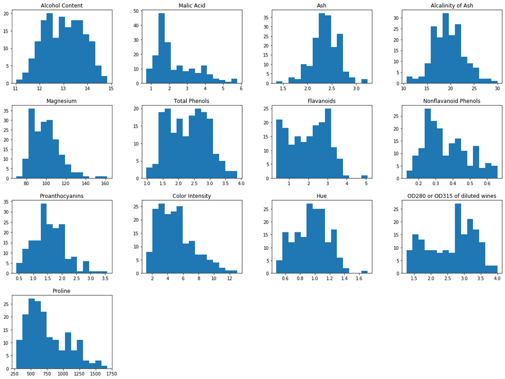

```python
# One Dimensional EDA (histogram)
fig = plt.figure(figsize=(20,15))
fig.subplots_adjust(hspace=0.3, wspace=0.3)
for i in range(1, 14):
    plt.subplot(4, 4, i)
    plt.hist(wine[wine.columns[i]], bins=15)
    plt.title(wine.columns[i])
plt.show()
```

## 4.2 Categorical Attributes (Pre-assigned label)

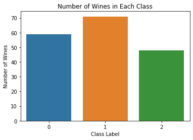

```python
axis = sns.barplot(x=y.value_counts().index,y=y.value_counts().values)
axis.set_xlabel("Class Label")
axis.set_ylabel("Number of Wines")
plt.title("Number of Wines in Each Class")
plt.show()
```

```python
y.value_counts()
```

```
1    71
0    59
2    48
Name: Wine Class, dtype: int64
```

There are in total three kinds of wines in our dataset. The first class contains 59 samples, the second class contains 71 samples and the third class contains 48 samples.

## 4.3 pairwise relationships

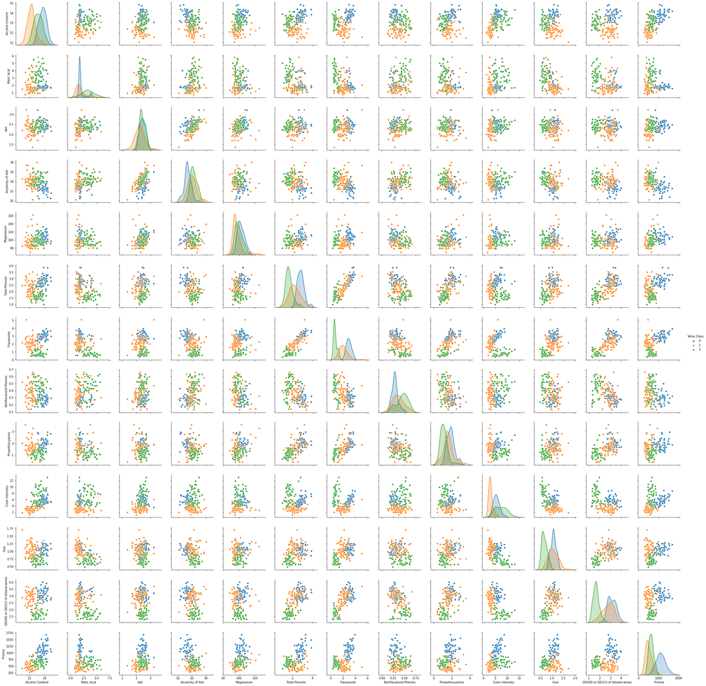

```python
sns.pairplot(wine,hue="Wine Class")
plt.show()
```

## 4.4 Scale Data

According to the summary statistic table, we should scale the data since the scale of different variables are different. For example, some variables have a range that is less than 1 while other variables are greater than 100.

Also, we draw the t-SNE plot for the raw dataset and the scaled dataset separately (the plot is in the next section) and find that the structure of the raw dataset is a line without any cluster structures.

Thus, we should perform z-score normalization to guarantee all variables are in the same range.

```python
sc = StandardScaler()
X_scaled = sc.fit_transform(X)
X_scaled_df = pd.DataFrame(X_scaled, columns=X.columns)
X_scaled_df.head()
```

|  | Alcohol Content | Malic Acid | Ash | Alcalinity of Ash | Magnesium | Total Phenols | Flavanoids | Nonflavanoid Phenols | Proanthocyanins | Color Intensity | Hue | OD280 or OD315 of diluted wines | Proline |
| --- | --- | --- | --- | --- | --- | --- | --- | --- | --- | --- | --- | --- | --- |
| 0 | 1.518613 | -0.562250 | 0.232053 | -1.169593 | 1.913905 | 0.808997 | 1.034819 | -0.659563 | 1.224884 | 0.251717 | 0.362177 | 1.847920 | 1.013009 |
| 1 | 0.246290 | -0.499413 | -0.827996 | -2.490847 | 0.018145 | 0.568648 | 0.733629 | -0.820719 | -0.544721 | -0.293321 | 0.406051 | 1.113449 | 0.965242 |
| 2 | 0.196879 | 0.021231 | 1.109334 | -0.268738 | 0.088358 | 0.808997 | 1.215533 | -0.498407 | 2.135968 | 0.269020 | 0.318304 | 0.788587 | 1.395148 |
| 3 | 1.691550 | -0.346811 | 0.487926 | -0.809251 | 0.930918 | 2.491446 | 1.466525 | -0.981875 | 1.032155 | 1.186068 | -0.427544 | 1.184071 | 2.334574 |
| 4 | 0.295700 | 0.227694 | 1.840403 | 0.451946 | 1.281985 | 0.808997 | 0.663351 | 0.226796 | 0.401404 | -0.319276 | 0.362177 | 0.449601 | -0.037874 |

## 4.5 Correlation heatmap

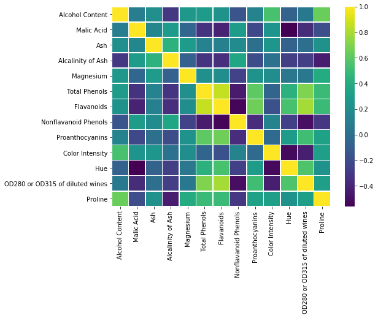

```python
corr = X_scaled_df.corr()
plt.figure(figsize=(8,6))
sns.heatmap(corr, linewidths=.5, cmap='viridis');
```

# 5. Pre-Analysis Questions

## 5.1 Is the dataset clusterable?

### 5.1.1 Hopkins statistic

```python
n=len(wine)
num_trials=5
hopkins_stats=[]
for i in range(0,num_trials):
    n = len(X_scaled)
    p = int(0.1 * n)
    hopkins_stats.append(hopkins(X_scaled,p))
print(hopkins_stats)
```

```
[0.2963904703238161, 0.270161200656328, 0.28740010581460107, 0.25692769326087883, 0.25349243032072905]
```

Since the hokpins statistic is nondeterministic, we run it five times and the results are very similar. The hopkins statistic is around 0.28 which is not that close to 0, indicating that the dataset is clusterable but not shows a high cluster tendency. However, the hopkin's statistic is not a foolproof method for different datasets. Thus, we will try to corroborate our clusterability assessments with multiple analyses such as the t-SNE plot.

### 5.1.2 t-SNE plot

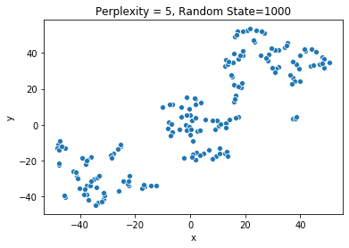

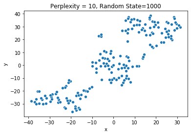

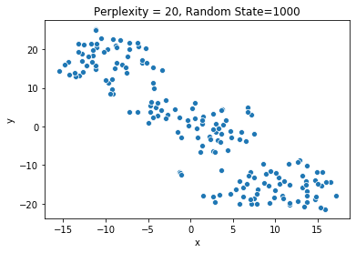

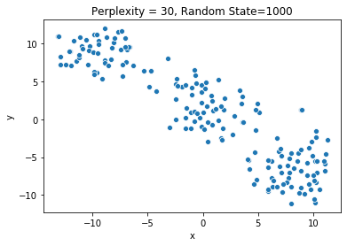

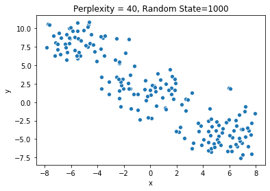

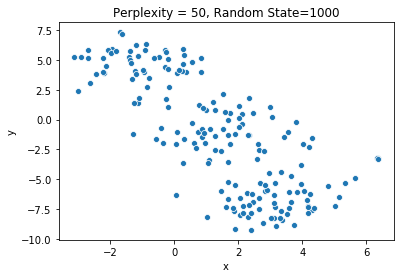

```python
for perp in [5,10,20,30,40,50]:
    # Perform the TSNE non-linear dimensionality reduction
    tsne = TSNE(n_components=2, perplexity=perp, random_state=1000)
    data_tsne = tsne.fit_transform(X_scaled)

    #concatenate the projected (x,y) coordinates (df_tsne) and the original dataset (df) into the same dataset.
    df_tsne = pd.DataFrame(data_tsne, columns=['x', 'y'], index=wine.index)
    dff = pd.concat([wine, df_tsne], axis=1)

    # Plot the projected (x,y) coordinates
    sns.scatterplot(x='x', y='y', data=dff)
    plt.title('Perplexity = %s, Random State=1000' %perp)
    plt.show()
```

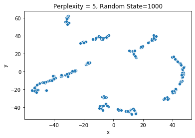

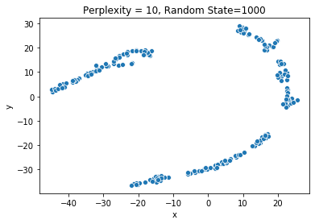

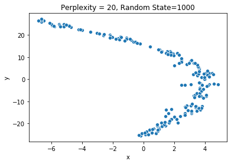

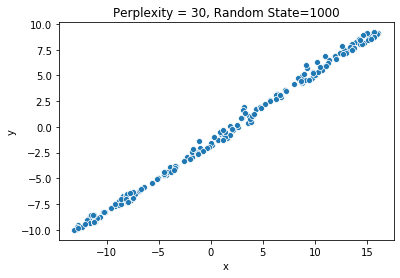

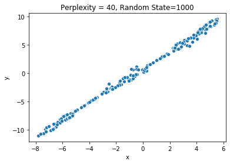

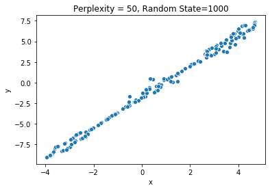

```python
# t-SNE plot (unscaled)
for perp in [5,10,20,30,40,50]:
    # Perform the TSNE non-linear dimensionality reduction
    tsne = TSNE(n_components=2, perplexity=perp, random_state=1000)
    data_tsne = tsne.fit_transform(X)

    #concatenate the projected (x,y) coordinates (df_tsne) and the original dataset (df) into the same dataset.
    df_tsne = pd.DataFrame(data_tsne, columns=['x', 'y'], index=wine.index)
    dff = pd.concat([wine, df_tsne], axis=1)

    # Plot the projected (x,y) coordinates
    sns.scatterplot(x='x', y='y', data=dff)
    plt.title('Perplexity = %s, Random State=1000' %perp)
    plt.show()
```

## 5.2 Underlying Clustering Structure

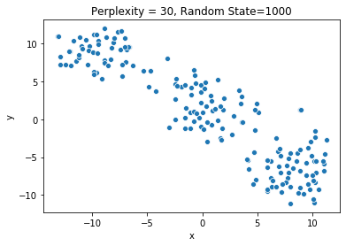

```python
# the most informativec t-SNE plot (scaled data with perplexity=30)

# Perform the TSNE non-linear dimensionality reduction
tsne = TSNE(n_components=2, perplexity=30, random_state=1000)
data_tsne = tsne.fit_transform(X_scaled)

#concatenate the projected (x,y) coordinates (df_tsne) and the original dataset (df) into the same dataset.
df_tsne = pd.DataFrame(data_tsne, columns=['x', 'y'], index=wine.index)
dff = pd.concat([wine, df_tsne], axis=1)

# Plot the projected (x,y) coordinates
sns.scatterplot(x='x', y='y', data=dff)
plt.title('Perplexity = %s, Random State=1000' %30)
plt.show()
```

According to the t-SNE plot using the scaled dataset with perplexity = 30, we could get several findings:

1) The t-SNE plot shows that there are roughly three clusters in our dataset.

2) Each cluster has spherical shape.

3) Clusters have almost the same size and well separated.

4) There are some points between two clusters, indicating that there are some overlaps between clusters.

# 6. Algorithm Selection Motivation

All of these information also support us to use K-means.

One thing worth mentioning is that, there is no significant outliers in this dataset, so we do not consider using density-based clustering, because we do not want the algorithm to filter out the noise for us.

Other than K-means, we are also trying agglomerative hierarchical clustering, a "bottom-up" approach: each observation starts in its own cluster, and pairs of clusters are merged as one moves up the hierarchy. At the beginning of the process, each element is in a cluster of its own. The clusters are then sequentially combined into larger clusters until all elements end up being in the same cluster. The method is also known as farthest neighbour clustering. The result of the clustering can be visualized as a dendrogram, which shows the sequence of cluster fusion and the distance at which each fusion took place.

Last but not least, we are also performing fuzzy c-means clustering, just to compensate the fact that our first two algorithms are both hard assignments. Fuzzy c-means will provide us membership scores which reflects the assignment uncertainty in a straightforward way, so adding this algorithm in would make our analysis more flexible.

# 7. Clustering Algorithms

## 7.1 K-Means

### 7.1.1 Parameter Setting

For the K-Means algorithm, we need to determine the number of clusters (K) for our dataset. To select the optimal K, we use the metric of inertia with elbow method.

```python
# use average inertia for selecting the best K (elbow method)
cluster_num_list=range(1,10)
avg_inertia_list=[]
for k in cluster_num_list:
    sub_inertia_list=[]
    for rs in [1001,1002,1003]: # use three random states
        kmeans=KMeans(n_clusters=k,random_state=rs).fit(X_scaled)
        sub_inertia_list.append(kmeans.inertia_)
    avg_inertia_list.append(np.average(sub_inertia_list)) # use the mean of the three trails
```

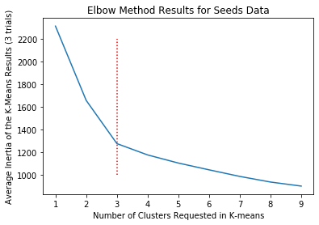

```python
# plot the avg inertia wrt K
plt.plot(cluster_num_list,avg_inertia_list)
plt.xlabel('Number of Clusters Requested in K-means')
plt.ylabel('Average Inertia of the K-Means Results (3 trials)')
plt.title('Elbow Method Results for Seeds Data')
plt.vlines(x=3, ymin=1000, ymax=2200, colors='red', ls=':', lw=1.5)
plt.show()
```

Interpretation:

As the number of clusters increases, the average inertia of K-means decreases. According to the principle of the elbow method, we prefer to the number of cluster that lies at the "elbow" which is the point after which the inertia start decreasing in a linear fashion. This elbow plot starts to level off at k=3 clusters. So the elbow plot is indicating that k-means will perform best with k=3 clusters.

### 7.1.2 Results Presentation

```python
kmeans=KMeans(n_clusters=3).fit(X_scaled)
wine['pred_clu_kmeans']=kmeans.labels_
```

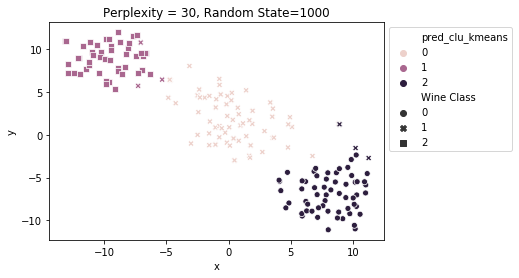

```python
# replot the t-SNE plot with the new assigned labels and styled by truth class

# Perform the TSNE non-linear dimensionality reduction
tsne = TSNE(n_components=2, perplexity=30, random_state=1000)
data_tsne = tsne.fit_transform(X_scaled)

#concatenate the projected (x,y) coordinates (df_tsne) and the original dataset (df) into the same dataset.
df_tsne = pd.DataFrame(data_tsne, columns=['x', 'y'], index=wine.index)
dff = pd.concat([wine, df_tsne], axis=1)

# Plot the projected (x,y) coordinates
sns.scatterplot(x='x', y='y', hue='pred_clu_kmeans', style='Wine Class', data=dff)
plt.title('Perplexity = 30, Random State=1000')
plt.legend(bbox_to_anchor=(1,1))
plt.show()
```

It looks like k-means identified the three clusters that we expected we would find given the t-sne plot.

### 7.1.3 K-Means Post Analysis

#### 7.1.3.1 Separation and Cohesion

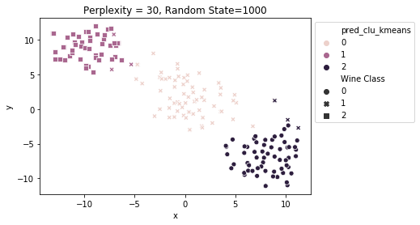

```python
# replot the t-SNE plot with the new assigned labels and styled by truth class

# Perform the TSNE non-linear dimensionality reduction
tsne = TSNE(n_components=2, perplexity=30, random_state=1000)
data_tsne = tsne.fit_transform(X_scaled)

#concatenate the projected (x,y) coordinates (df_tsne) and the original dataset (df) into the same dataset.
df_tsne = pd.DataFrame(data_tsne, columns=['x', 'y'], index=wine.index)
dff = pd.concat([wine, df_tsne], axis=1)

# Plot the projected (x,y) coordinates
sns.scatterplot(x='x', y='y', hue='pred_clu_kmeans', style='Wine Class', data=dff)
plt.title('Perplexity = 30, Random State=1000')
plt.legend(bbox_to_anchor=(1,1))
plt.show()
```

```python
# silhouette score for assessing cohesion and separation of individual objects in a given clustering
silhouette_avg_kmenas = silhouette_score(X_scaled, wine['pred_clu_kmeans'])
print("The average silhouette_score for the K-Means is :", silhouette_avg_kmenas)
```

```
The average silhouette_score for the K-Means is : 0.2848589191898987
```

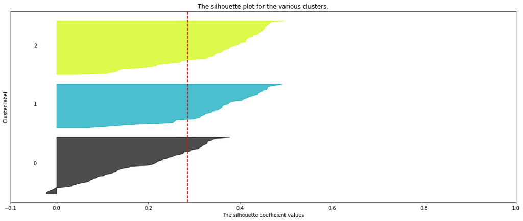

```python
# Compute the silhouette scores for each sample
sample_silhouette_values = silhouette_samples(X_scaled, wine['pred_clu_kmeans'])

n_clusters=len(wine['pred_clu_kmeans'].unique())


fig, ax1 = plt.subplots(1, 1)
fig.set_size_inches(18, 7)

# The 1st subplot is the silhouette plot
# The silhouette coefficient can range from -1, 1 but in this example all
# lie within [-0.1, 1]
ax1.set_xlim([-0.1, 1])
# The (n_clusters+1)*10 is for inserting blank space between silhouette
# plots of individual clusters, to demarcate them clearly.
ax1.set_ylim([0, len(X) + (n_clusters + 1) * 10])


y_lower = 10
for i in range(n_clusters):
    # Aggregate the silhouette scores for samples belonging to
    # cluster i, and sort them
    ith_cluster_silhouette_values = \
        sample_silhouette_values[wine['pred_clu_kmeans'] == i]

    ith_cluster_silhouette_values.sort()

    size_cluster_i = ith_cluster_silhouette_values.shape[0]
    y_upper = y_lower + size_cluster_i

    color = cm.nipy_spectral(float(i) / n_clusters)
    ax1.fill_betweenx(np.arange(y_lower, y_upper),
                      0, ith_cluster_silhouette_values,
                      facecolor=color, edgecolor=color, alpha=0.7)

    # Label the silhouette plots with their cluster numbers at the middle
    ax1.text(-0.05, y_lower + 0.5 * size_cluster_i, str(i))

    # Compute the new y_lower for next plot
    y_lower = y_upper + 10  # 10 for the 0 samples

ax1.set_title("The silhouette plot for the various clusters.")
ax1.set_xlabel("The silhouette coefficient values")
ax1.set_ylabel("Cluster label")

# The vertical line for average silhouette score of all the values
ax1.axvline(x=silhouette_avg_kmenas, color="red", linestyle="--")

ax1.set_yticks([])  # Clear the yaxis labels / ticks
ax1.set_xticks([-0.1, 0, 0.2, 0.4, 0.6, 0.8, 1])


plt.show()
```

The closer this score is to 1, the more cohesive and separated these clustering is. So an average silhouette score of 0.28 is somewhat low. So even though the t-SNE plot shows that the class labels are almost correctly predicted, the underlying cohesion and separation of this dataset is not strong, in which there are some connections among different kinds of wines.